# GSA workflow tutorial

Fanny Sarrazin

2022-03-01

The goal of this session is to give a flavour of Sensitivity Analysis (SA) by application of several methods to a simple rainfall-runoff model. The uncertain inputs subject to SA are the model parameters. The aim is to assess the impact of the uncertainty in these parameters on the model’s ability to reproduce streamflow observations, as measured by different performance metrics:  
- the Root Mean Squared Error (RMSE)  
- the volumetric bias (BIAS)

The analysis will be conducted using the [SAFE(R/Python/Matlab) Toolbox](https://safetoolbox.info) (Pianosi et al., 2015).

#### Programme

**1. Model setup and One-At-a-Time Sensitivity Analysis** (OAT).  
Load the data and get confident with the rainfall-runoff model (Hymod).

**2. Visual and qualitative Global Sensitivity Analysis** (GSA).  
Perform **Monte Carlo simulations** (forward propagation of uncertainty): sample the model parameters within their ranges and run the model to obtain an ensemble of runoff predictions. Use a visual and qualitative GSA method for a preliminary assessment of sensitivity (scatterplots).

**3. Regional Sensitivity Analysis** (RSA).  
Use RSA to formally assess the effect of parameter variations on the model outputs (Young et al., 1978; Spear and Hornberger, 1980; Saltelli et al., 2008).

**4. Regional Sensitivity Analysis based on grouping**.  
Use RSA based on grouping to assess the output sensitivity without specifying a single threshold on output values (Wagener et al., 2001).

For further exploration (try another GSA method):

**5. Variance-Based Sensitivity Analysis** (VBSA). Use VBSA to measure output sensitivity and compare with RSA results (Sobol’, 1990; Homma and Saltelli, 1996; Saltelli et al. 1999; Saltelli et al., 2008; Saltelli et al. 2010).

Throughout the session, we will also examine the impact of several key choices on SA results:  
- the threshold value for RSA  
- the output (scalar) metric  
- the sample size for the Monte Carlo simulations  
- the parameter ranges  
- the SA method  
Further investigation of these choices can be found in Noacco et al. (2019), and a general discussion on the topic is also provided in Pianosi et al. (2016) and in Wagener and Pianosi (2019). The choice of sample size is more specifically discussed in Sarrazin et al. (2016).

#### The Hymod rainfall-runoff model and the case study catchment

We will use the Hymod model (Boyle 2001; Wagener et al. 2001), that produces a time series of streamflow predictions as output. The model is composed of a soil moisture accounting routine, and a flow routing routine, which in its turn is composed of a fast and a slow routing pathway.

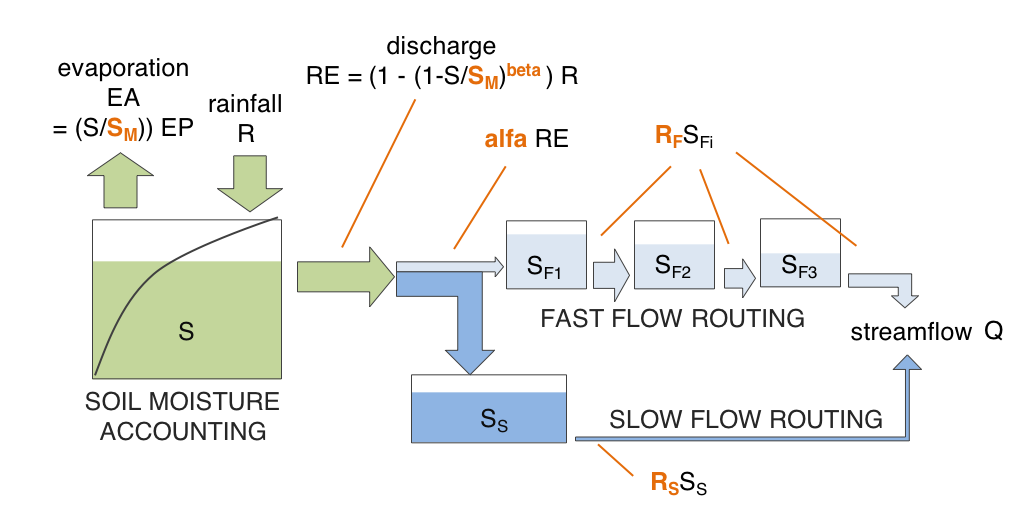

Hymod includes 5 parameters:  
$S_M$: the maximum soil moisture (mm) (soil moisture)  
$beta$: the exponent in the soil moisture (-) (soil moisture)  
$alfa$: the partition coefficient (-) (routing)  
$R_S$: the slow reservoir coefficient (-) (routing)  
$R_F$: the fast reservoir coefficient (-) (routing)

The model is applied to the Leaf catchment in the USA (Sorooshian et al., 1983).

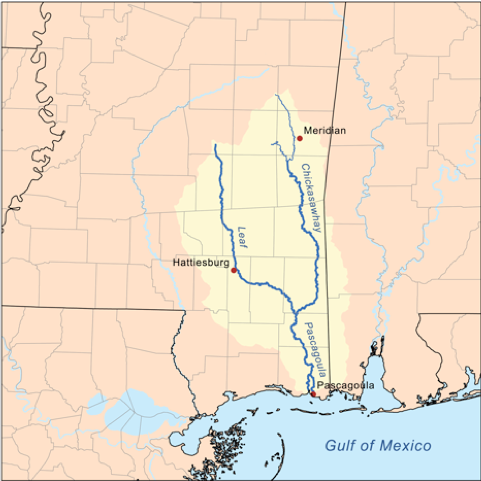

The model forcing input data are:  
1-year daily observations of rainfall (R) [columns 1 in *LeafCatch.txt*]  
1-year daily observations potential evaporation (PE) [column 2 in *LeafCatch.txt*]

We will also used output measurements: 1-year daily observations of streamflow (Q) [columns 3 in *LeafCatch.txt*]

For this application, we can use the following ranges of feasible variations of the parameters:  
$S_M \in$ [0,400] (mm)  
$beta\in$ [0,2] (-)  
$alfa\in$ [0,1] (-)  
$R_S \in$ [0,0.1] (-)  
$R_F \in$ [0.1,1] (-)

#### 0. Installation and loading of packages

In R (or RStudio) install the SAFER package:

```r
path_SAFER <- "Y:/Home/sarrazin/SAFE/SAFE_R/" # Path to SAFER package (Change it to your own path before running!)

install.packages("caTools")
install.packages("ggplot2")
install.packages("cowplot")
install.packages("gridExtra")
install.packages("FRACTION")
install.packages("matrixStats")
install.packages(paste(path_SAFER, "safer_1.2.1/calibrater_0.51.tar.gz", sep=""), repos = NULL, type = "source")
install.packages(paste(path_SAFER, "safer_1.2.1/SAFER_1.2.1.tar.gz", sep=""), repos = NULL, type = "source")
```

Load the required packages:

```r
library(caTools)
library(calibrater)
library(cowplot)
library(gridExtra)
library(FRACTION)
library(matrixStats)
library(ggplot2)
library(SAFER)

# Finally execute the functions in the file 'additional_functions.R'
# This file contains the following functions:
# - RMSE and BIAS: compute summary output metrics
# - hymod_sim_workshop: simulate the Hymod model
```

#### 1. Model setup and One-At-a-Time Sensitivity Analysis

Load and plot the data (one year of daily observations of rainfall, potential evaporation and flow):

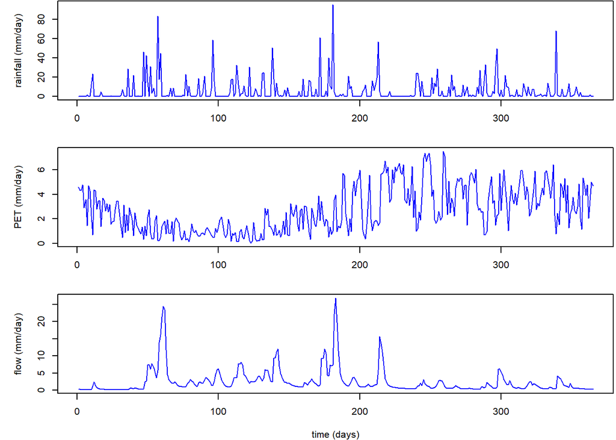

```r
data(LeafCatch)
dat <- LeafCatch[1:365,] # select the first year of data
warmup <- 30 # set warming-up period

# Plot data:
par(mfrow = c(3, 1),mar=c(4, 5, 0.1, 0.2))
plot(dat[ ,1],type="l",col="blue",ylab="rainfall (mm/day)",xlab = "")
plot(dat[ ,2],type="l",col="blue",ylab="PET (mm/day)",xlab = "")
plot(dat[ ,3],type="l",col="blue",ylab="flow (mm/day)",xlab = "time (days)")
```

Define the function to simulate the Hymod model:

```r
hymod_sim_workshop <- function(param, rain, evap){

## --------------------------
## Recover model parameters:
## --------------------------
Sm <- max(.Machine$double.eps, param[1]) # Maximum Soil Moisture (cannot be zero!)
beta <- param[2] # Exponential parameter in soil routine [-]
alfa <- param[3] # Partitioning factor [-]
Rs   <- param[4] # Slow reservoir outflow coefficient (ratio) [1/Dt]
Rf   <- param[5] # Fast reservoir outflow coefficient (ratio) [1/Dt]

N_step <- length(rain) # number of time steps in the simulation horizon

## -----------------------
## Initialize variables:
## ----------------------
Pe  <- numeric(N_step) # Recharge from the soil [mm/Dt]
Ea  <- numeric(N_step) # Actual Evapotranspiration [mm/Dt]
sm <- numeric(N_step + 1) # Soil Moisture [mm]
sL <- numeric(N_step + 1) # Slow reservoir moisture [mm]
sF1 <- numeric(N_step + 1) # Fast reservoir 1 moisture [mm]
sF2 <- numeric(N_step + 1) # Fast reservoir 2 moisture [mm]
sF3 <- numeric(N_step + 1) # Fast reservoir 3 moisture [mm]

QsL <- numeric(N_step)  # Slow flow [mm/Dt]
QsF <- numeric(N_step)  # Fast flow [mm/Dt]

# simulation:
for (t in 1:N_step){

    # --------------------------
    #   Soil Moisture Dynamics:
    # --------------------------

    FF  <- 1 - ( 1 - sm[t] / Sm )^beta
    Pe[t] <- FF * rain[t] # Compute the value of the outflow
    # (we assumed that this process is faster than evaporation)

    sm_temp  = max(min(sm[t] + rain[t] - Pe[t], Sm), 0) # Compute the water
  # balance with the value of the outflow
  Pe[t] = Pe[t] + max(sm[t] + rain[t] - Pe[t] - Sm, 0) + min(sm[t] + rain[t] - Pe[t], 0)
  # adjust Pe by an amount equal to the possible negative sm amount or
  # to the possible sm amount above Sm.

  W = min(abs(sm[t] / Sm ),1) # Correction factor for evaporation
  Ea[t] = W * evap[t] # Compute the evaporation
  sm[t+1] = max(min(sm_temp - Ea[t], Sm), 0) # Compute the water balance
  Ea[t]= Ea[t] + max(sm_temp - Ea[t] - Sm, 0) + min(sm_temp - Ea[t], 0) # adjust Ea
  # by an amount equal to the possible negative sm amount or to the
  # possible sm amount above Sm

  # -------------------------
  #   Groundwater Dynamics:
  # -------------------------

  # slow flow
  QsL[t] <- Rs * sL[t]
    sL[t+1] <- sL[t] + (1 - alfa) * Pe[t] - QsL[t]
    # fast flow
    sF1[t+1] <- sF1[t] +  alfa * Pe[t] - Rf * sF1[t]
    sF2[t+1] <- sF2[t] +  Rf * sF1[t] - Rf * sF2[t]
    QsF[t]  <- Rf * sF3[t]
    sF3[t+1] <- sF3[t] +  Rf * sF2[t] - QsF[t]

}

Qsim <- QsL + QsF
STATES <- list(sm = sm,sL = sL, sF1 = sF1, sF2 = sF2, sf3 = sF3)
FLUXES <- list(Pe = Pe, Ea = Ea, QsL = QsL, QsF = QsF)
attributes(Qsim) <- list(STATES = STATES, FLUXES = FLUXES)
return(Qsim)
}
```

Set the parameters to some tentative values, run the model and plot the resulting streamflow time series:

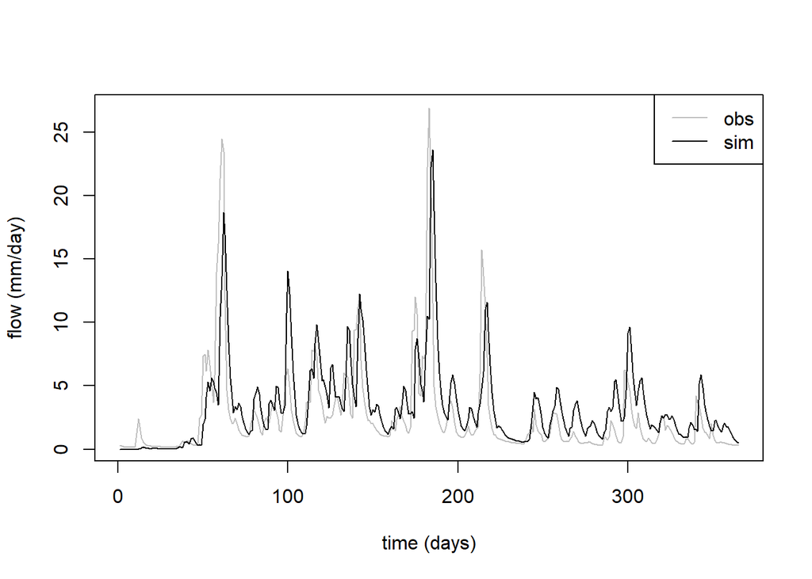

```r
# Set a tentative parameterization:
param = c(200,0.5,0.7,0.05,0.6)
# Run simulation:
flow_sim <- hymod_sim_workshop(param, dat$rain, dat$evap)
# Plot results:
plot(dat$flow,type="l",col="grey",xlab="time (days)",ylab="flow (mm/day)")
lines(flow_sim,col="black")
legend("topright", legend = c("obs", "sim"),col = c("grey", "black"), lty = c(1))
```

#### One-At-a-Time (OAT) effect

Change one parameter - for instance $alfa$ - and repeat the same steps:

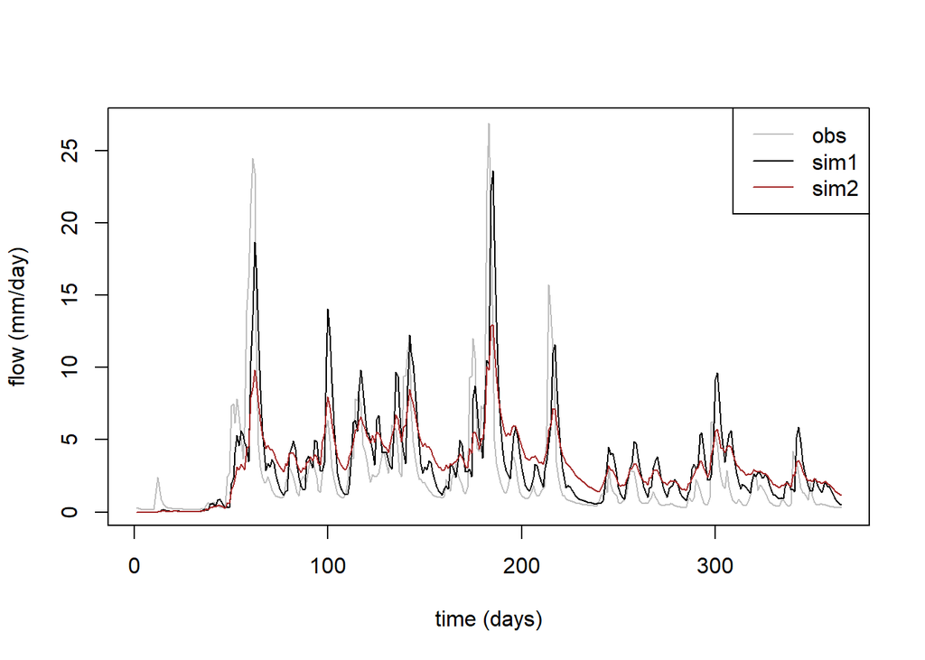

```r
# Change alfa:
param = c(200,0.5,0.2,0.05,0.6)
flow_sim2 <- hymod_sim_workshop(param, dat$rain, dat$evap)
plot(dat$flow,type="l",col="grey",xlab="time (days)",ylab="flow (mm/day)")
lines(flow_sim,col="black")
lines(flow_sim2,col="brown")
legend("topright", legend = c("obs", "sim1","sim2"),col = c("grey", "black","brown"), lty = c(1))
```

**Questions:**  
*What is the effect of varying this parameter (and the others)?*  
*Which parameter controls which characteristic (timing, peak, recession phase, etc.) of the simulated flow time series?*  
*Which parameters seem to mostly influence the output?*  
*What are the pros and cons of OAT sensitivity analysis?*

$$\begin{array}{l}
-------------------------------------------------------------- \\
\\
-------------------------------------------------------------- \\
\\
-------------------------------------------------------------- \\
\end{array}$$

### 2. Visual and qualitative Global Sensitivity Analysis

In this section, we run Monte Carlo (MC) simulations of the model against a certain number of input (parameter) samples. Each model simulation provides a times series of runoff predictions. To measure the accuracy of each of these times series with respect to observations, we define two aggregate output metrics to be used for the subsequent steps, *the Root Mean Squared Error (RMSE) and the volumetric bias (BIAS) of the streamflow predictions*.

Input (parameter) sampling (this involves a number of choices that will be assessed and revised later on):

```r
# Define input variability space:
DistrFun  <- "unif" # Define parameter distributions
DistrPar  <- list( c(0, 400), c(0, 2), c(0, 1), c(0, 0.1), c(0.1, 1)) # Define parameter ranges
x_labels <- c("Sm", "beta", "alfa", "Rs", "Rf") # Define parameter names (used to customize plots)
M <- length(DistrPar) # Number of parameters

# Choose sampling strategy and size:
SampStrategy <- "lhs" # "lhs" = Latin Hypercube sampling
N <- 150 # Choose the number of samples

# Perform sampling:
X <- AAT_sampling(SampStrategy, M, DistrFun, DistrPar, N)
colnames(X) <- x_labels
# If you want to see what the sample 'X' looks like:
X[1:10 ,] # Print to screen the first 10 samples
```

```
##                 Sm       beta      alfa          Rs        Rf
## sample1  377.38150 0.08887278 0.4440640 0.005258613 0.4324953
## sample2  365.11293 0.78907092 0.7290941 0.077808031 0.2182769
## sample3  347.09245 1.06271065 0.4368348 0.088469367 0.8257203
## sample4  150.59754 0.34237354 0.3537294 0.093061606 0.2668319
## sample5   61.57680 0.99628028 0.7898750 0.046933777 0.9219133
## sample6  153.70208 0.87071881 0.1997850 0.061021511 0.5012593
## sample7  338.35423 0.73372302 0.1795596 0.019710067 0.5829370
## sample8  291.28203 0.01319930 0.9753968 0.096935551 0.2923442
## sample9   38.62536 1.13995142 0.2205758 0.086635718 0.4604022
## sample10  30.56639 1.24507821 0.6785722 0.073911565 0.8276638
```

Model execution:

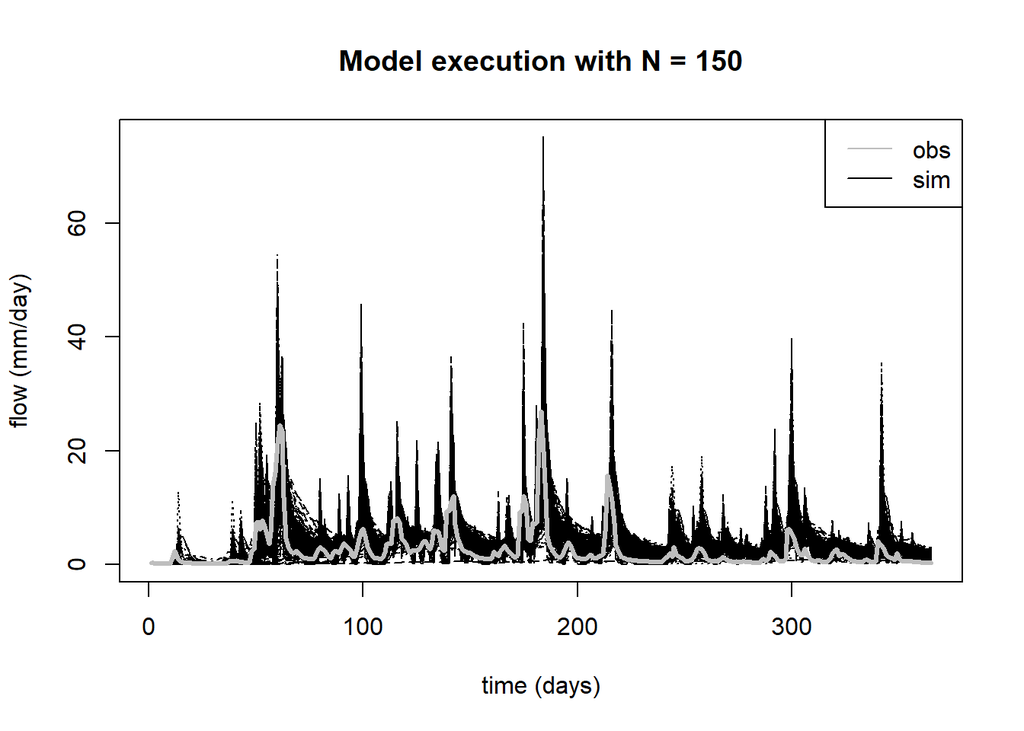

```r
# Execute the model against all the input samples in 'X':
QQ <- apply(X,1,hymod_sim_workshop,dat$rain,dat$evap)

# Plot Monte Carlo (MC) simulations results and compare with data:
matplot(QQ, type="l",col="black",xlab="time (days)",ylab="flow (mm/day)", main = paste0("Model execution with N = ",N))
lines(dat$flow,col="grey", lwd = c(3))
legend("topright", legend = c("obs", "sim"),col = c("grey", "black"), lty = c(1))
```

Definition of summary output metrics:

```r
RMSE <- function(Qs, Qo){
   RMSE <-numeric(1)
   RMSE <- sqrt(mean((Qs - Qo)^2)) # RMSE
   return(RMSE)
}

BIAS <- function(Qs, Qo){
   BIAS <-numeric(1)
   BIAS <- abs(mean(Qs - Qo)) # BIAS
   return(BIAS)
}
```

#### Check model behaviour by visualising input/output samples with scatterplots

Computation and visualisation of the output metrics:

```r
# Aggregate output time series into various scalar output metric(s):
YY <- matrix(, nrow = N, ncol = 2)
YY[,1] <- apply(QQ[(warmup+1):nrow(QQ),],2,RMSE,dat$flow[(warmup+1):nrow(dat)]) # RMSE
YY[,2] <- apply(QQ[(warmup+1):nrow(QQ),],2,BIAS,dat$flow[(warmup+1):nrow(dat)]) # BIAS
colnames(YY) <- c("RMSE","BIAS")

# If you want to see what the sample 'Y' looks like:
dim(YY) # Check the dimension of YY
```

```
## [1] 150   2
```

```r
YY[1:10 ,] # Print to screen the first 10 samples
```

```
##           RMSE      BIAS
##  [1,] 3.796448 0.6786815
##  [2,] 3.778474 0.7859027
##  [3,] 2.816340 1.0620808
##  [4,] 3.095637 0.8559958
##  [5,] 5.415332 1.5077923
##  [6,] 3.005991 1.2142891
##  [7,] 3.539273 0.5187177
##  [8,] 4.295207 0.1442568
##  [9,] 2.995750 1.6661214
## [10,] 4.211609 1.7606866
```

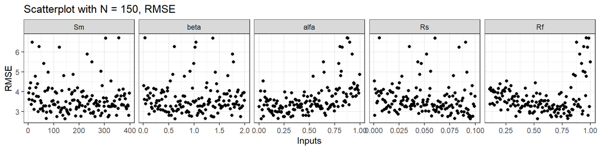

```r
# Select the output metric to be analysed (uncomment option you want to view):
Y = YY[, 1, drop = FALSE] # RMSE
# Y = YY[, 2, drop = FALSE] # BIAS

# Scatter plots of the output metric against input samples:
scatter_plots(X,Y, prnam = x_labels) + ylab(colnames(Y)) + ggtitle(paste0("Scatterplot with N = ",N, ", ", colnames(Y)))
```

**Questions:**  
*From these scatter plots, which parameters would you say are the most influential? Why?*  
*Are there parameters that are not influential at all?*

$$\begin{array}{l}
-------------------------------------------------------------- \\
\\
-------------------------------------------------------------- \\
\\
-------------------------------------------------------------- \\
\end{array}$$

### 3. Regional Sensitivity Analysis

In this section, we formally assess the sensitivity of the output metrics (RMSE and BIAS) to the model parameters through the Regional Sensitivity Analysis (RSA) method (Young et al., 1978; Spear and Hornberger, 1980; Saltelli et al., 2008). The steps of RSA are:

[1] Choose a threshold value for the output metric(s).
[2] Split the input-output sample into two groups: *Behavioural* (output value below the threshold) and *Non-behavioural* (above).
[3] Compare the input sub-samples, for instance by comparing their Cumulative Distribution Functions (CDFs). Sensitivity can be assessed visually or measured quantitatively, e.g. by the Kolmogorov-Smirnov statistic (denoted as KS and which is the maximum vertical distance between the CDFs):
$$S_i = \max_q |F_{x_i|x_i \in \mathcal{B}}(q)-F_{x_i|x_i \in \mathcal{N}}(q)|$$

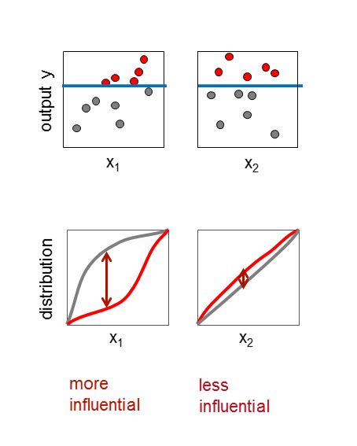

Split sample into behavioural and non-behavioural sub-samples:

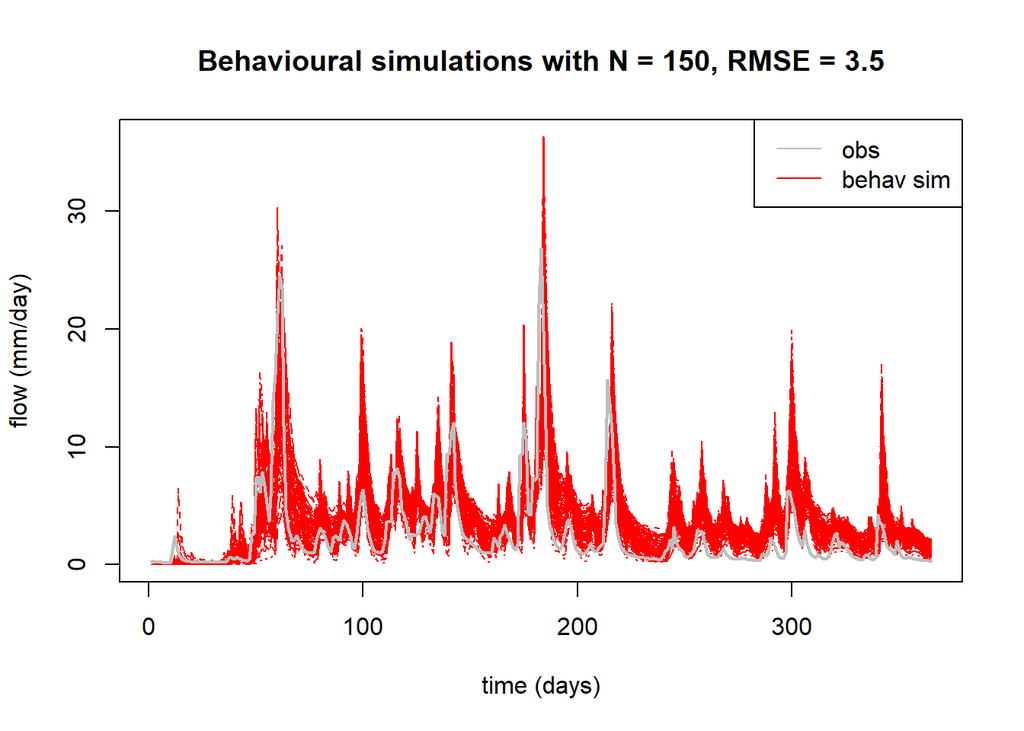

```r
# Define the threshold:
threshold = 3.5
# Use the function RSA_indices_thres to split into behavioural (Y<threshold) and non-behavioural (Y>threshold) sample:
rsatr <- RSA_indices_thres(X, Y, threshold)
# To learn what the function 'RSA_indices_thres' does, type:
# ?RSA_indices_thres
# Recover indices of behavioural samples:
idxb <- rsatr$idxb

# Plot behavioural MC simulations:
QQb <- QQ[,idxb]
matplot(QQb, type="l",col="red",xlab="time (days)",ylab="flow (mm/day)", main = paste0("Behavioural simulations with N = ",N, ", ", colnames(Y)," = ",threshold))
lines(dat$flow,col="grey", lwd = c(2))
legend("topright", legend = c("obs", "behav sim"),col = c("grey", "red"), lty = c(1))
```

Let’s now replot the results with the function `scatter_plots` highlighting the behavioural parameterizations:

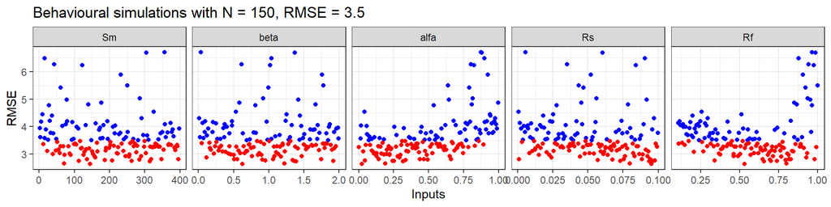

```r
scatter_plots_tr(X, Y, prnam = x_labels, idx = idxb) + ylab(colnames(Y)) + ggtitle(paste0("Behavioural simulations with N = ",N, ", ", colnames(Y)," = ",threshold))
```

```r
# (red = behavioural, blue = non-behavioural)
```

Compare the input CDFs of the behaviour and non-behavioural subsample:

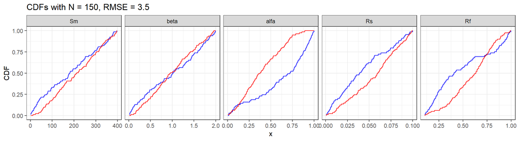

```r
# Plot CDFs of behavioural and non-behavioural input samples:
RSA_plot_thres(X, idxb, prnam = x_labels, threshold) + scale_color_manual(values=c("blue","red")) + ggtitle(paste0("CDFs with N = ",N, ", ", colnames(Y)," = ",threshold))
```

```r
# (red = behavioural, blue = non-behavioural)
```

**Questions:**  
*From the CDF plots, which parameters would you say are the most influential? Why?*  
*Are these results consistent with the visual analysis of the scatter plots?*

$$\begin{array}{l}
-------------------------------------------------------------- \\
\\
-------------------------------------------------------------- \\
\\
-------------------------------------------------------------- \\
\end{array}$$

Compute the KS statistic (maximum vertical distance between the two CDFs of the inputs):

```r
# Extract the value of KS statistic:
rsatr$stat
```

```
## [1] 0.1680086 0.1068170 0.4288782 0.2657005 0.3279656
```

Here the KS statistic is plotted.

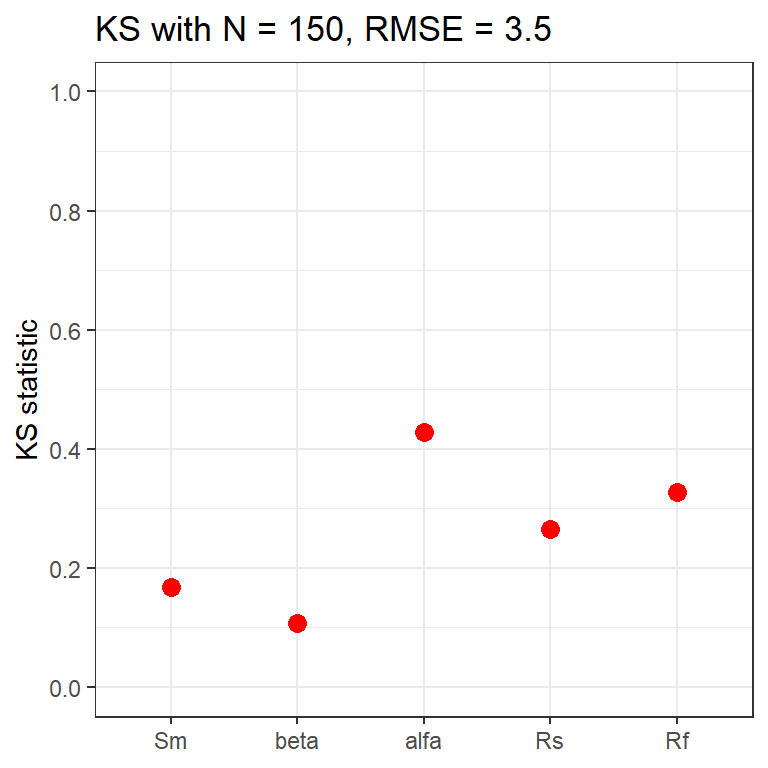

```r
boxplot1(rsatr$stat, prnam = x_labels) + ggtitle(paste0("KS with N = ",N, ", ", colnames(Y)," = ",threshold)) + ylab("KS statistic")
```

**Questions:**  
*Are the KS values consistent with the visual inspection of the CDF plots?*  
*Did you get the same KS values as the other participants? Why?*

$$\begin{array}{l}
-------------------------------------------------------------- \\
\\
-------------------------------------------------------------- \\
\\
-------------------------------------------------------------- \\
\end{array}$$

#### 3.1 Assess the effect of the change in threshold

Let’s choose a different threshold and re-run the analysis:

```r
# Define the threshold:
threshold = 3
# Use the function RSA_indices_thres to split into behavioural (Y<threshold) and non-behavioural (Y>threshold) sample:
rsatr_tr2 <- RSA_indices_thres(X, Y, threshold)

# Recover indices of behavioural samples:
idxb_tr2 <- rsatr_tr2$idxb
```

[figure not shown]

```r
scatter_plots_tr(X, Y, prnam = x_labels, idx = idxb) + ylab(colnames(Y)) + ggtitle(paste0("Behavioural simulations with N = ",N, ", ", colnames(Y)," = ",threshold))
```

```r
# (red = behavioural, blue = non-behavioural)
```

Compare the input CDFs of the behaviour and non-behavioural subsample with the new threshold:

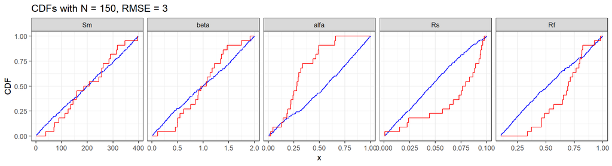

```r
# Plot CDFs of behavioural and non-behavioural input samples:
RSA_plot_thres(X, idxb_tr2, prnam = x_labels, threshold) + scale_color_manual(values=c("blue","red")) + ggtitle(paste0("CDFs with N = ",N, ", ", colnames(Y)," = ",threshold))
```

```r
# (red = behavioural, blue = non-behavioural)
```

Plot the KS statistic (maximum vertical distance between the two CDFs of the inputs).

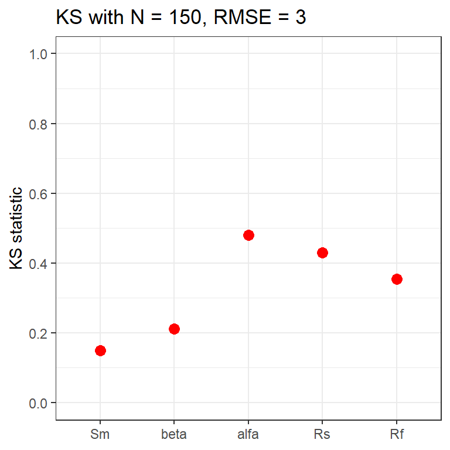

```r
boxplot1(rsatr_tr2$stat, prnam = x_labels) + ggtitle(paste0("KS with N = ",N, ", ", colnames(Y)," = ",threshold)) +  ylab("KS statistic")
```

*How have the results changed by changing the threshold of the output metric?*

$$\begin{array}{l}
-------------------------------------------------------------- \\
\\
-------------------------------------------------------------- \\
\\
-------------------------------------------------------------- \\
\end{array}$$